# Bayesian hierarchical models for space-temporal modeling of COVID-19 in Catalonia. Vaccination analysis

26 junio, 2023

# 1 Description

Full vaccination is defined as administrations of second doses or administrations of one shot (J&J) vaccines. For the analysis, we will consider the cumulative percentage of full vaccination individuals as weekly rates don’t take in account previous history of vaccines administered. Because administered vaccines in a given time point can have an effect in posterior time outcomes,we have to take in account all the entire vaccination history in that area.

Table 1: Descriptive table of the cumulative full vaccination counts and percentage of all ABS in the whole period

|  | N = 373 |
| --- | --- |
| ABS cumulative full vaccination counts |  |
| Mean (SD) | 16881.12 (7483.76) |
| Median (IQR) | 16857.00 (11581.00, 21506.00) |
| ABS cumulative full vaccination percentage (%) |  |
| Mean (SD) | 80.93 (3.65) |
| Median (IQR) | 81.38 (78.44, 83.37) |

Figure 1: Plot of the evolution of the weekly full vaccination rate per 100k habitants across the study period

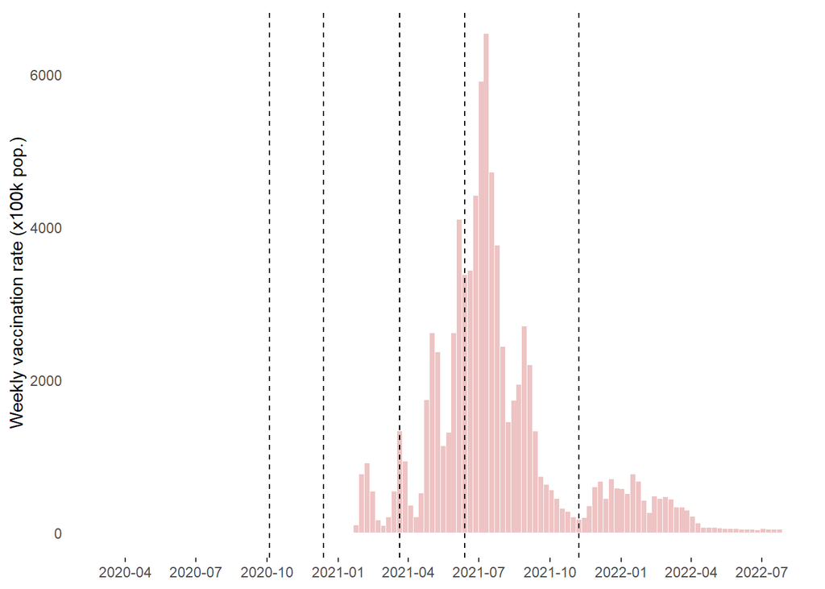

The 5th wave is were daily rates of full vaccination have their peak.

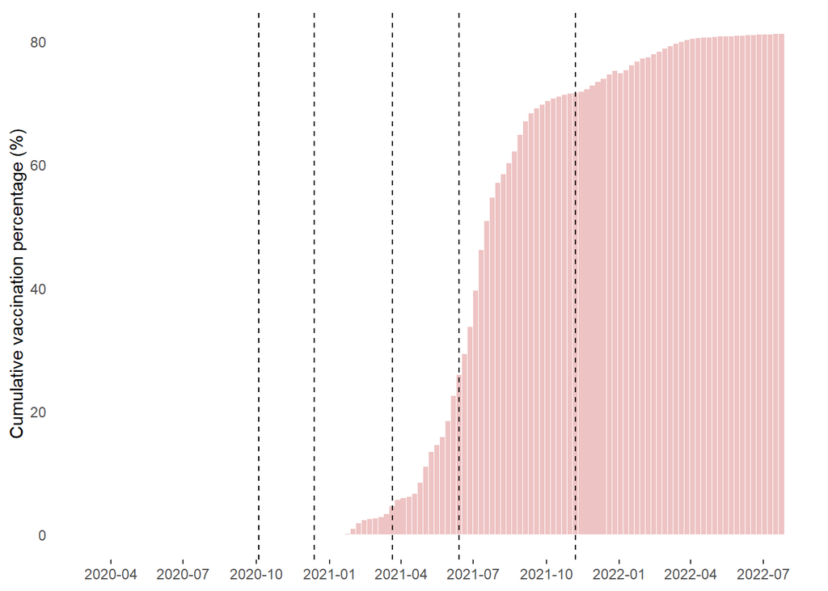

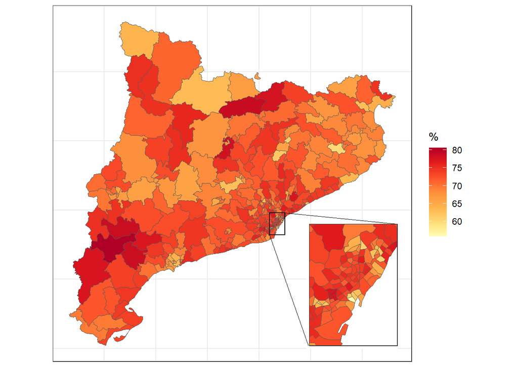

Figure 4: Plot of the weekly fully vaccinated percentage by each of the sanitary regions along with the median across time

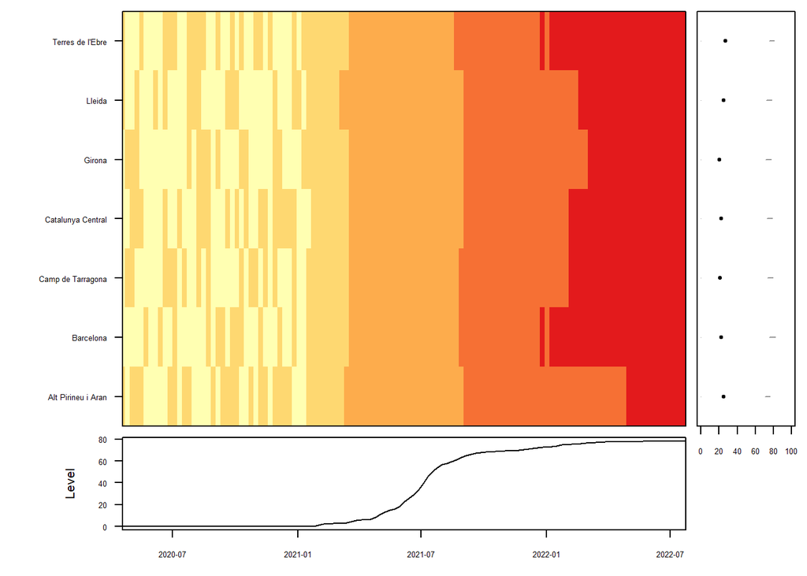

There’re no differences in the pattern of each region as we measure a cumulative variable that is more difficult to have variability.

Let’s see the distribution of the cumulative full vaccination percentage by age and sex groups.

Figure 5: Cumulative full vaccination percentage in the whole period by sex groups

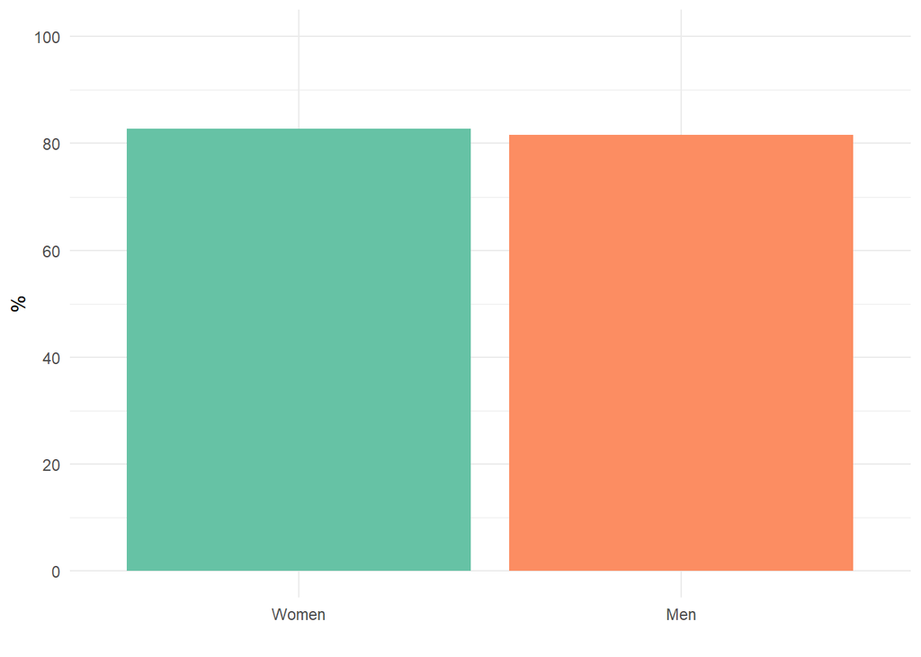

The vaccination percentage is very similar between the two sex groups.

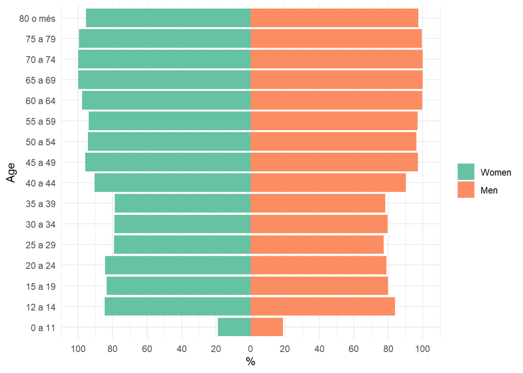

The oldest age groups are more vaccinated than the rest. The minimum age for vaccination is of 5 years. There’re some groups of age that have a 100% of cumulative full vaccination. This can happen because we’re counting J&J vaccines that in some individuals it was given twice after the fully immunization.

Figure 7: Evolution of the daily full vaccination percentage in function of the sex group

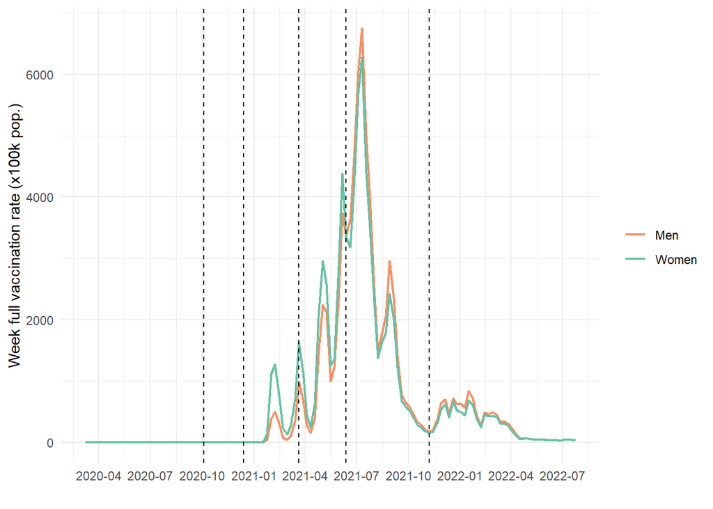

In the beginning of the vaccination campaign the percentage of full vaccination in women was higher than in men while in the 4th wave it was compensated a bit. This might happen because there is more old women than old men and the first vaccinated population were the oldest one.

Figure 8: Evolution of the daily full vaccination rate in function of the age group (bigger or lower than 70 years)

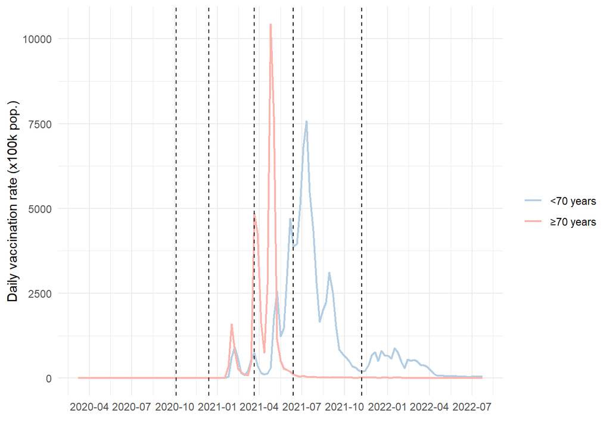

In the first weeks of the vaccination campaign the full vaccination percentage of the oldest group is a lot bigger than in the youngest group (3th-4th wave) as they were vaccination before the younger population. In fact, from the 5th wave the rate of full vaccination of people older than 70 years old is nearly zero.

Figure 9: Boxplot of cumulated full vaccination coverage in function of urban/rural areas

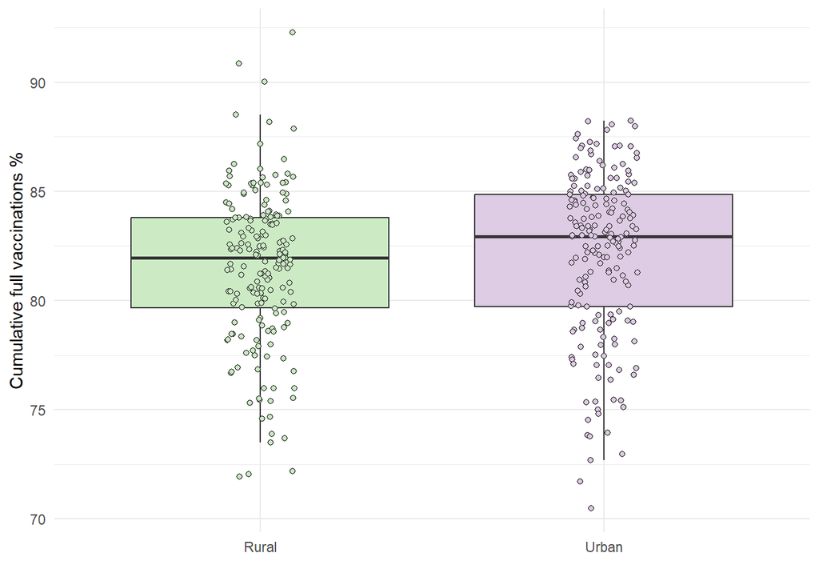

We see that in general urban areas have a a little bit percentage of cumulative vaccinations.

# 2 Analysis

We would like to assess the effect of the fully vaccinated weekly percentage in each area and each time. We will consider lagged values of the weekly percentage of vaccination, as being fully vaccinated doesn’t give you inmediate inmutity and also the virus has an incubation time.

Furthermore, this is a complicated task as we’re trying the assess a causal effect of a temporal variable and the conditions of the pandemic changes in time (testing efforts, covid-19 variants, restrictions in place…) so there can be many potential confounders. Because of this, we will try to stratify the period of analysis considering waves that have similar pandemic conditions. Nevertheless, we think that taking the expected values calculated at each week we’re intrinsically controlling by the temporal conditions of the pandemic in all the territory although differences between the areas that change across time might still have a confounding role in the effect of study.

First, we will consider all the period. We will take one week more from the start because we want to study the effect of the lagged vaccination. Thus, we will start at the week of 2021-01-24.

Second, we will consider only the period between the beginning of the vaccination campaign (2021-01-03) in the 3rd wave until the end of the 4th wave (2021-06-13). This period is pretty homogeneous as the delta variant comes in the beginning of the 5th wave, the testing effort is the same and the restrictions in this period doesn’t change much, dominated by the night curfew and the restrictions on meetings. Only in the beginning of may the night curfew restriction is lifted with the end of alarm state. The limitation of taking this period is that the percentage of fully vaccinated population is low in the beginning so it won’t have a big effect on the outcomes.

Third, we will consider only the period in the 5th wave where the delta variant is predominant and the restrictions are not very tight (only midnight curfew is imposed in a short period in the incidence pick). The limitation of this period is that the variability of the vaccination percentage across the areas drops a lot in the 5th wave as most of the areas have a similar fully vaccinated percentage.

Finally, as we have seen the majority of people with 70 years old or more are vaccinated in the 3rd-4th wave. Thus, in this period we will study the effect of the full vaccination on the hospitalization outcome only taking in account the population older than 70 years old. In this group of age it is believed that vaccination has a bigger effect.

The models that have been considered in each scenario are the following:

- Raw spatio-temporal model
- Model adjusted only by the lagged vaccine effect
- Model adjusted by the lagged vaccine effect + Spatial covariates
- Model adjusted by the non-lagged vaccine effect + Spatial covariates
- Model adjusted by the SIR of the lagged vaccine effect + Spatial covariates

We will see that the results show that if we estimate the models with the SIR calculated in the whole period we generally see a strong effect of the vaccination, whereas if we calculate the SIR by week we also see a protective effect but it is close to significance. I think that because there is not enough variability on the vaccination in the different areas it’s difficult for this variable to explaine the spatial variance of the outcomes, but it has more of an effect explaining the temporal variance. Thus, it’s more complicated to get a effect on the model on the SIR by each week because it already incorporates intrinsically the temporal effect introducing the expected values of each week as an offset. Nevertheless, the results on the SIR with expected values in the whole period might still be confounded, although stratifying by waves, because we are trying to explain a quadratic effect of the vaccination in the geenral temporal trend with a linear one.

## 2.1 All period

Figure 10: Plot of the evolution of the distribution of fully vaccinated percentage between areas (the median along with the interquantile range is represented) across all the period

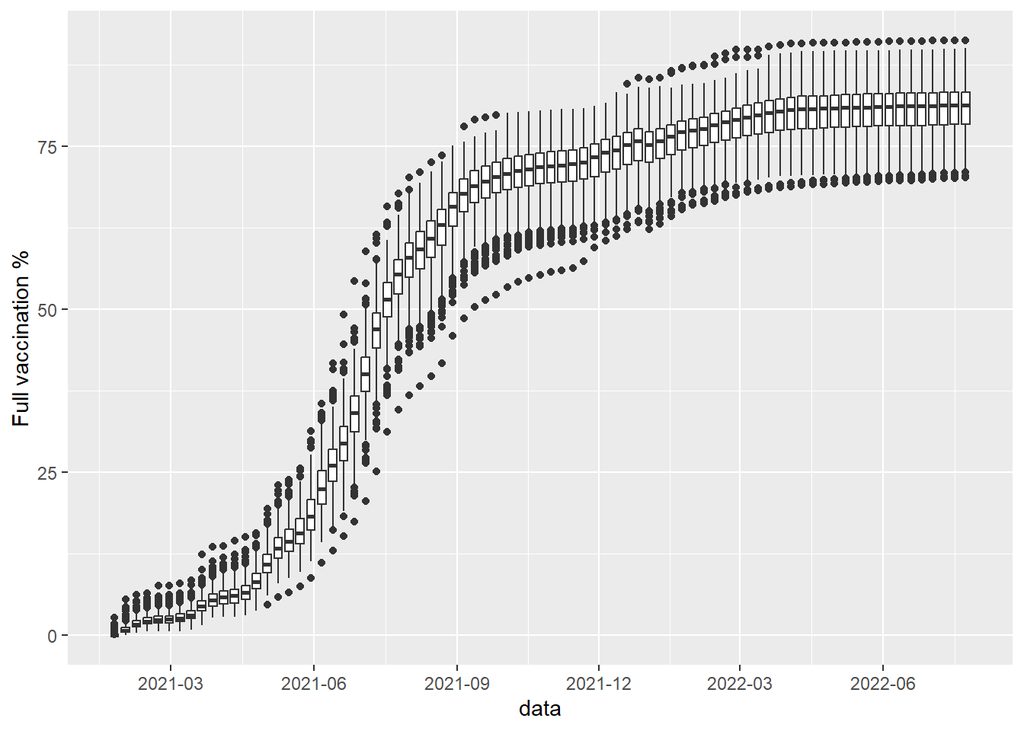

### 2.1.1 SIR by week

First, let’s illustrate the differences in the cumulative full vaccination percentage in all the period between the hot/cold spots estimated by the raw model on the hospitalization outcome.

Figure 11: Difference on the vaccination rates between hot/mild/cold spots given by the residual spatial effect of the raw model on hospitalizations

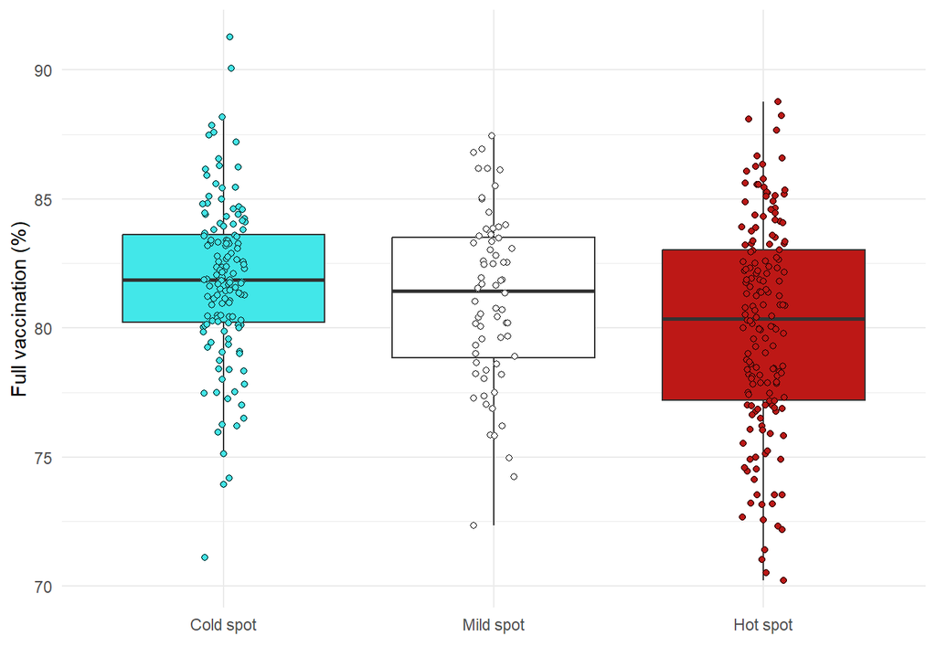

Hot spots have lower full vaccination percentages than cold spots, so we might think that the vaccination could explain some of the spatial effect.

Let’s show the differences on the cumulative full vaccination percentage of the previous week between the estimated hot/cold spots of the actual week, for all the weeks of the study period.

Figure 12: Difference on the vaccination rates between hot/cold spots given by the residual spatio-temporal effect of the raw model on hospitalizations

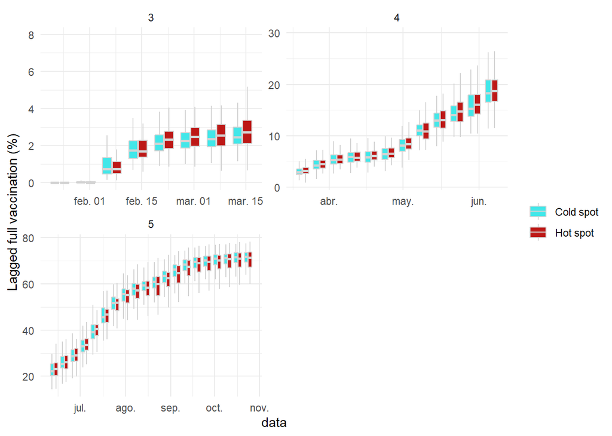

We can’t see clear differences on the lagged cumulative full vaccination percentage between hot and cold spots.

Figure 13: Difference on the vaccination rates between hot/cold spots given by the posterior RR effect of the raw model on hospitalizations

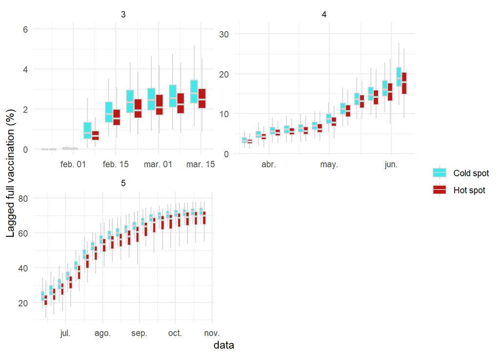

It seems that across all period hot spots have systematically lower lagged cumulative values of full vaccination percentages than cold spots.

Table 2: Description of estimated DIC and WAIC for all the models

|  | Cases DIC | Cases WAIC | Hospitalization DIC | Hospitalization WAIC |
| --- | --- | --- | --- | --- |
| Raw | 94843.31 | 95358.28 | 50173.04 | 49435.40 |
| Vaccination |  |  | 50167.25 | 49433.23 |
| Vaccination + Covariates | 94820.90 | 95316.92 | 50182.76 | 49452.61 |
| Vaccination (2-week lag) | 94788.89 | 95289.46 | 50180.18 | 49449.34 |

For the cases outcome, adjusted models improve the model. For the hospitalization outcome, vaccination model alone fits better the data but adjusting by covariates doesn’t fit better the data.

Let’s explore the linearity of the relationships between the cumulative vaccination at the end of the studied period and the estimated spatial RR by the raw model.

Figure 14: Plot of the estimated spatial RR of the raw model on cases for each ABS in function of each one of the cumulative fully vaccination percentage at the end of the studied period

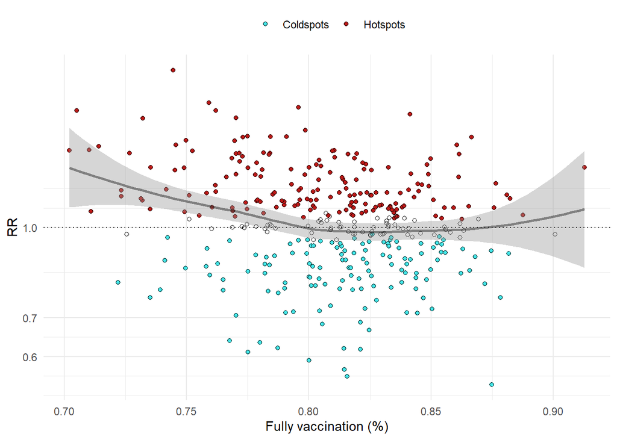

Figure 15: Plot of the estimated spatial RR of the raw model on hospitalisations for each ABS in function of the fully vaccination that we will include in the model

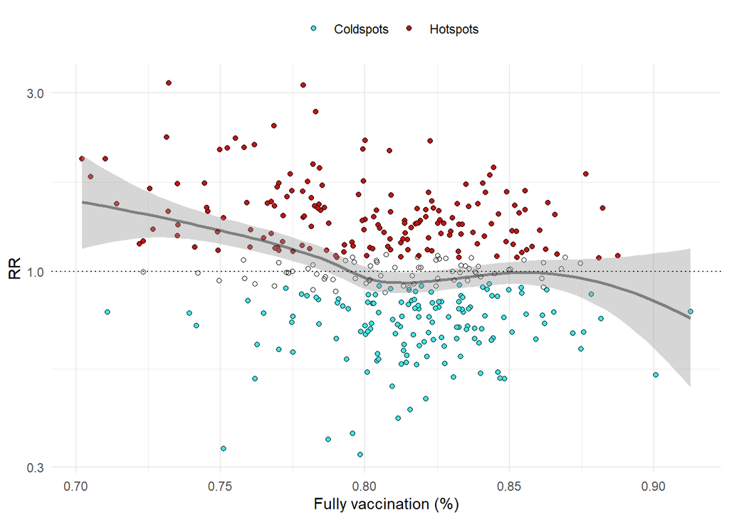

Table 3: Estimated fixed effects and hyperparameters for each model on the cases outcome

|  | Raw | Vaccination + Covariates | Vaccination (2-week lag) |
| --- | --- | --- | --- |
| **Fixed effects** |  |  |  |
| (Intercept) | 0.88 (0.87, 0.9) | 0.85 (0.83, 0.88) | 0.85 (0.83, 0.88) |
| Urban vs Rural |  | 1.07 (1.02, 1.13) | 1.07 (1.01, 1.13) |
| Socioeconomic Index (SI) |  | 1.02 (1, 1.04) | 1.02 (1, 1.04) |
| Full vaccination (1-week lag) |  | 0.94 (0.85, 1.01) |  |
| Full vaccination (2-week lags) |  |  | 0.99 (0.96, 1.03) |
| **Random effects** |  |  |  |
| SD (idarea) | 0.18 (0.2, 0.16) | 0.19 (0.21, 0.17) | 0.21 (0.23, 0.19) |
| Phi for idarea | 0.57 (0.46, 0.69) | 0.74 (0.55, 0.89) | 0.9 (0.86, 0.94) |
| SD (idtime) | 0.02 (0.03, 0.01) | 0.01 (0.02, 0.01) | 0.02 (0.02, 0.02) |
| SD (idareatime) | 0.31 (0.31, 0.3) | 0.31 (0.31, 0.3) | 0.31 (0.31, 0.3) |

The vaccination has a protective effect of 6% at the significance limit. Considering 2-week lags this effect disappears.

$\phi$ values increase for adjusted models.

Table 4: Percentage of explained variability by the spatial, temporal and spatio-temporal patterns of every model on the cases outcome

|  | Variance Spatial (%) | Variance Temporal (%) | Variance Spatio-Temporal (%) |
| --- | --- | --- | --- |
| Raw | 24.55 | 0.29 | 75.16 |
| Vaccination + Covariates | 28.35 | 0.19 | 71.46 |
| Vaccination (2-week lag) | 32.14 | 0.26 | 67.61 |

The spatial variance increases in detriment of the temporal and spatio-temporal variance.

Table 5: Estimated fixed effects and hyperparameters for each model on the hospitalization outcome

|  | Raw | Vaccination | Vaccination + Covariates | Vaccination (2-week lag) |
| --- | --- | --- | --- | --- |
| **Fixed effects** |  |  |  |  |
| (Intercept) | 0.84 (0.82, 0.87) | 0.84 (0.82, 0.86) | 0.77 (0.73, 0.82) | 0.77 (0.73, 0.82) |
| Full vaccination (1-week lag) |  | 0.94 (0.89, 1) | 0.96 (0.91, 1.01) |  |
| Urban vs Rural |  |  | 1.2 (1.08, 1.32) | 1.2 (1.08, 1.32) |
| Socioeconomic Index (SI) |  |  | 1.21 (1.17, 1.26) | 1.21 (1.17, 1.26) |
| Full vaccination (2-week lags) |  |  |  | 0.97 (0.94, 1.01) |
| **Random effects** |  |  |  |  |
| SD (idarea) | 0.42 (0.45, 0.38) | 0.43 (0.49, 0.38) | 0.33 (0.38, 0.3) | 0.35 (0.39, 0.32) |
| Phi for idarea | 0.71 (0.54, 0.84) | 0.78 (0.46, 0.94) | 0.62 (0.38, 0.83) | 0.68 (0.56, 0.83) |
| SD (idtime) | 0 (0.01, 0) | 0.01 (0.02, 0) | 0 (0.02, 0) | 0 (0.01, 0) |
| SD (idareatime) | 0.21 (0.22, 0.21) | 0.21 (0.22, 0.2) | 0.21 (0.22, 0.2) | 0.21 (0.22, 0.2) |

The vaccination has a protective effect of 6% on the risk of hospitalization very at limit of significance and when adjusting by covariates the effect decreases slightly to 4% and is at limit of significance. Moreover, considering 2-week lags it decreases to 3%.

The role of the structural spatial effect increases a little bit when adjusted by the vaccination and decreases when adjusting further by covariates.

Table 6: Percentage of explained variability by the spatial, temporal and spatio-temporal patterns of every model on the hospitalization outcome

|  | Variance Spatial (%) | Variance Temporal (%) | Variance Spatio-Temporal (%) |
| --- | --- | --- | --- |
| Raw | 80.12 | 0.01 | 19.87 |
| Vaccination | 80.17 | 0.04 | 19.79 |
| Vaccination + Covariates | 71.63 | 0.03 | 28.35 |
| Vaccination (2-week lag) | 72.35 | 0.03 | 27.62 |

The spatial variance decreases for the adjusted models in benefit of the spatio-temporal variance.

### 2.1.2 SIR whole period

First, let’s illustrate the differences in the cumulative full vaccination percentage in all the period between the hot/cold spots estimated by the raw model on the hospitalization outcome.

Figure 16: Difference on the vaccination rates between hot/mild/cold spots given by the residual spatial effect of the raw model on hospitalizations

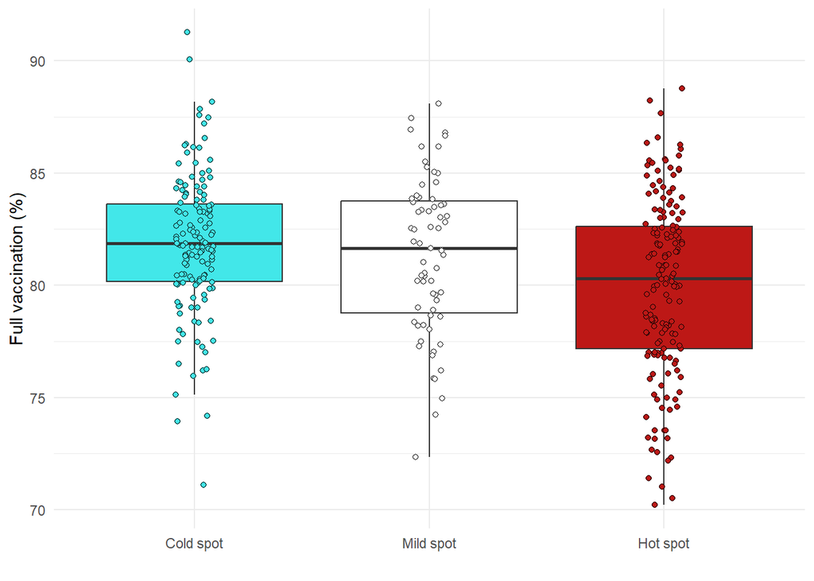

Hot spots have lower full vaccination percentages than cold spots, so we might think that the vaccination could explain some of the spatial effect.

Let’s show the differences on the cumulative full vaccination percentage of the previous week between the estimated hot/cold spots of the actual week, for all the weeks of the study period.

Figure 17: Difference on the vaccination rates between hot/cold spots given by the residual spatio-temporal effect of the raw model on hospitalizations

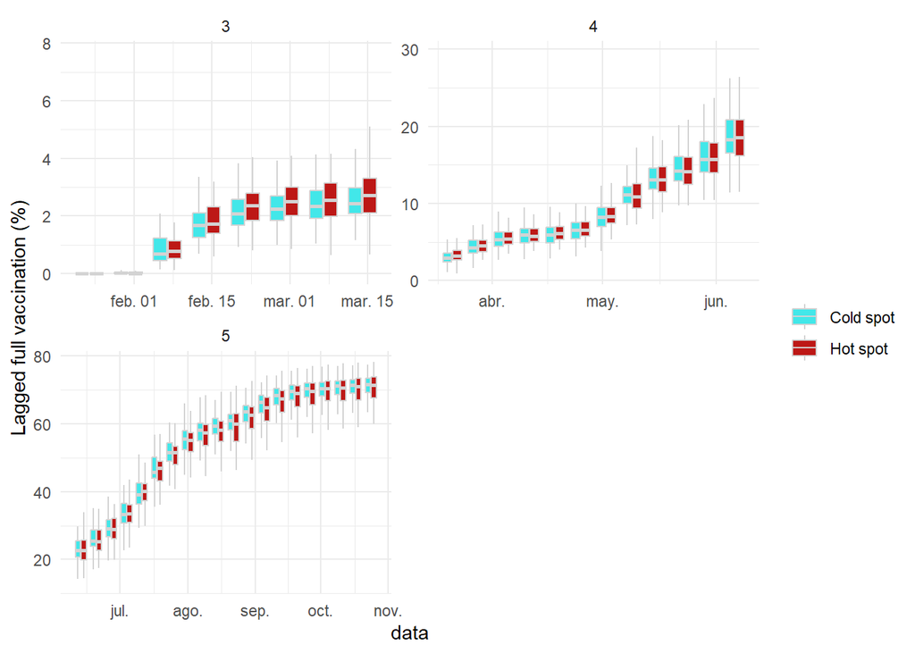

We can’t see clear differences on the lagged cumulative full vaccination percentage between hot and cold spots.

Figure 18: Difference on the vaccination rates between hot/cold spots given by the posterior RR effect of the raw model on hospitalizations

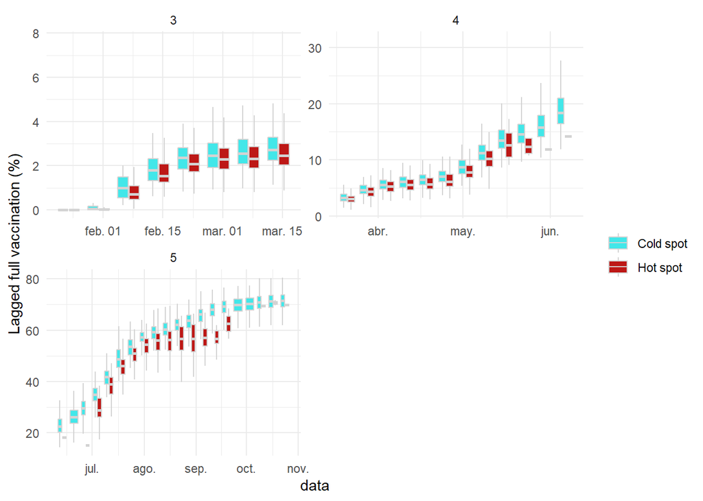

It seems that across all period hot spots have systematically lower lagged cumulative values of full vaccination percentages than cold spots. We see that with the SIR calculated using the whole period hot spots are found in the incidence peaks, meanwhile in the flat incidence periods there are few areas considered hot spots.

Table 7: Description of estimated DIC and WAIC for all the models

|  | Cases DIC | Cases WAIC | Hospitalization DIC | Hospitalization WAIC |
| --- | --- | --- | --- | --- |
| Raw | 94826.93 | 95316.86 | 50197.55 | 49452.25 |
| Vaccination |  |  | 50225.02 | 49486.49 |
| Vaccination + Covariates | 94812.33 | 95308.79 | 50223.71 | 49492.38 |
| Vaccination (2-week lag) | 94788.89 | 95289.46 | 50179.94 | 49449.03 |

Table 8: Estimated fixed effects and hyperparameters for each model on the cases outcome

|  | Raw | Vaccination + Covariates | Vaccination (2-week lag) |
| --- | --- | --- | --- |
| **Fixed effects** |  |  |  |
| (Intercept) | 0.34 (0.33, 0.34) | 0.32 (0.32, 0.33) | 0.85 (0.83, 0.88) |
| Urban vs Rural |  | 1.07 (1.01, 1.12) | 1.07 (1.01, 1.13) |
| Socioeconomic Index (SI) |  | 0.99 (0.97, 1.01) | 1.02 (1, 1.04) |
| Full vaccination (1-week lag) |  | 0.55 (0.47, 0.66) |  |
| Full vaccination (2-week lags) |  |  | 0.99 (0.96, 1.03) |
| **Random effects** |  |  |  |
| SD (idarea) | 0.19 (0.21, 0.17) | 0.18 (0.2, 0.16) | 0.21 (0.23, 0.19) |
| Phi for idarea | 0.7 (0.57, 0.84) | 0.74 (0.57, 0.88) | 0.9 (0.86, 0.94) |
| SD (idtime) | 0.34 (0.46, 0.26) | 0.35 (0.45, 0.28) | 0.02 (0.02, 0.02) |
| SD (idareatime) | 0.31 (0.31, 0.3) | 0.31 (0.31, 0.3) | 0.31 (0.31, 0.3) |

The vaccination have a high protective effect of the 45% adjusted by covariates. Taking 2-week lags the effect disappears.

The value of $\phi$ increases for the adjusted models.

Table 9: Percentage of explained variability by the spatial, temporal and spatio-temporal patterns of every model on the cases outcome

|  | Variance Spatial (%) | Variance Temporal (%) | Variance Spatio-Temporal (%) |
| --- | --- | --- | --- |
| Raw | 15.16 | 47.42 | 37.42 |
| Vaccination + Covariates | 13.09 | 50.26 | 36.65 |
| Vaccination (2-week lag) | 32.15 | 0.26 | 67.60 |

The spatial variance slightly decreases in benefit of the temporal variance for the 1-week lagged vaccination effect, and increases taking 2-week lags.

Table 10: Estimated fixed effects and hyperparameters for each model on the hospitalization outcome

|  | Raw | Vaccination | Vaccination + Covariates | Vaccination (2-week lag) |
| --- | --- | --- | --- | --- |
| **Fixed effects** |  |  |  |  |
| (Intercept) | 0.66 (0.64, 0.67) | 0.66 (0.64, 0.67) | 0.6 (0.57, 0.64) | 0.77 (0.73, 0.82) |
| Full vaccination (1-week lag) |  | 0.33 (0.25, 0.44) | 0.47 (0.36, 0.62) |  |
| Urban vs Rural |  |  | 1.19 (1.08, 1.31) | 1.2 (1.08, 1.32) |
| Socioeconomic Index (SI) |  |  | 1.17 (1.13, 1.22) | 1.21 (1.17, 1.26) |
| Full vaccination (2-week lags) |  |  |  | 0.97 (0.94, 1.01) |
| **Random effects** |  |  |  |  |
| SD (idarea) | 0.45 (0.49, 0.41) | 0.37 (0.42, 0.33) | 0.32 (0.36, 0.28) | 0.34 (0.39, 0.3) |
| Phi for idarea | 0.77 (0.48, 0.91) | 0.66 (0.46, 0.83) | 0.54 (0.3, 0.75) | 0.65 (0.42, 0.85) |
| SD (idtime) | 0.21 (0.28, 0.17) | 0.25 (0.32, 0.2) | 0.23 (0.3, 0.19) | 0.01 (0.02, 0.01) |
| SD (idareatime) | 0.21 (0.22, 0.2) | 0.21 (0.22, 0.21) | 0.21 (0.22, 0.2) | 0.21 (0.22, 0.2) |

Lagged vaccination has a high protective effect of 66% on the risk of hospitalization. When adjusting by covariates the effect is still high (53%). Considering 2-week lags the effect is small at limit of the significance.

The role of the structural spatial effect decreases for the adjusted models.

Table 11: Percentage of explained variability by the spatial, temporal and spatio-temporal patterns of every model on the hospitalization outcome

|  | Variance Spatial (%) | Variance Temporal (%) | Variance Spatio-Temporal (%) |
| --- | --- | --- | --- |
| Raw | 68.58 | 13.72 | 17.69 |
| Vaccination | 55.58 | 25.76 | 18.67 |
| Vaccination + Covariates | 49.86 | 27.58 | 22.57 |
| Vaccination (2-week lag) | 72.02 | 0.09 | 27.89 |

## 2.2 3rd and 4th wave

### 2.2.1 All population

Figure 19: Plot of the evolution of the distribution of fully vaccinated percentage between areas (the median along with the interquantile range is represented) across the 3rd and 4th wave

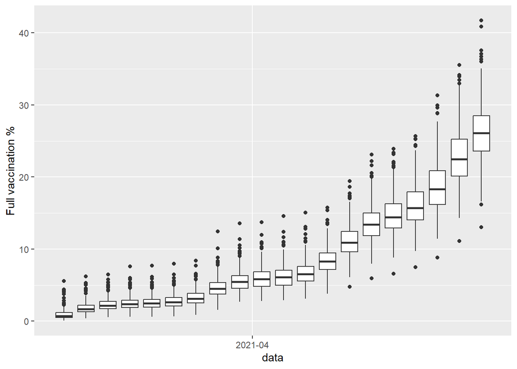

#### 2.2.1.1 SIR by week

First, let’s illustrate the differences in the cumulative full vaccination percentages in all the period between hospitalization hot/cold spots estimated by the raw model.

Figure 20: Difference on the vaccination rates between hot/mild/cold spots given by the residual spatial effect of the raw model on hospitalizations

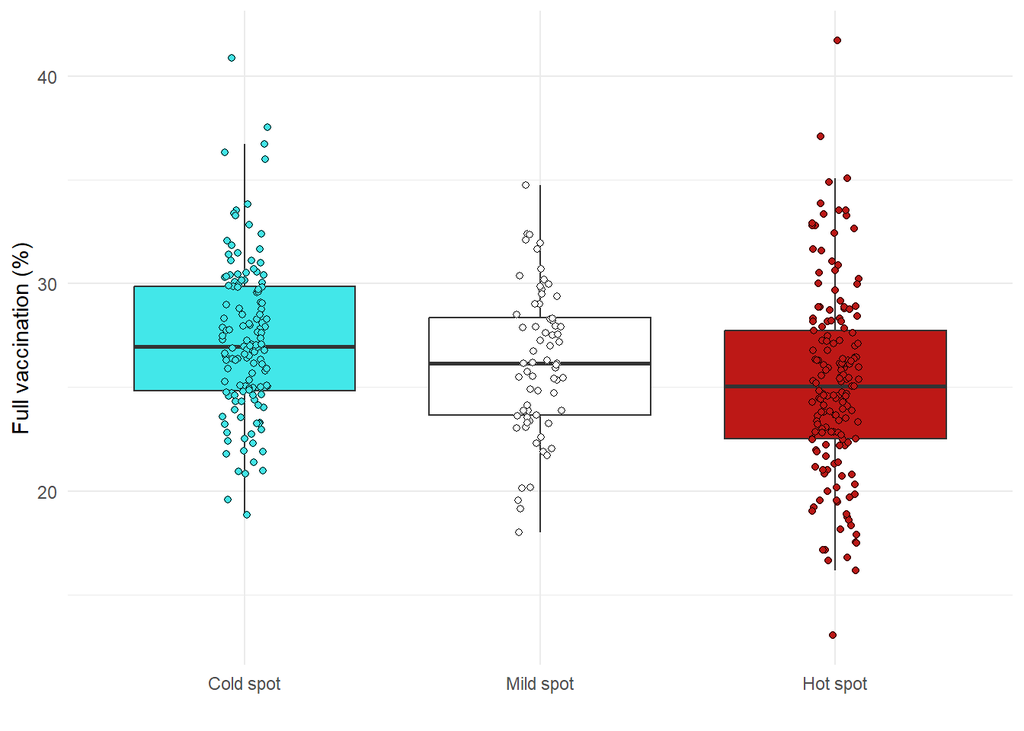

Hot spots have lower full vaccination percentages than cold spots, so we might think that the vaccination could explain some of the spatial effect.

Let’s show the differences on the cumulative full vaccination percentage of the previous week between the estimated hot/cold spots of the actual week, for all the weeks of the study period.

Figure 21: Difference on the vaccination rates between hot/cold spots given by the residual spatio-temporal effect of the raw model on hospitalizations

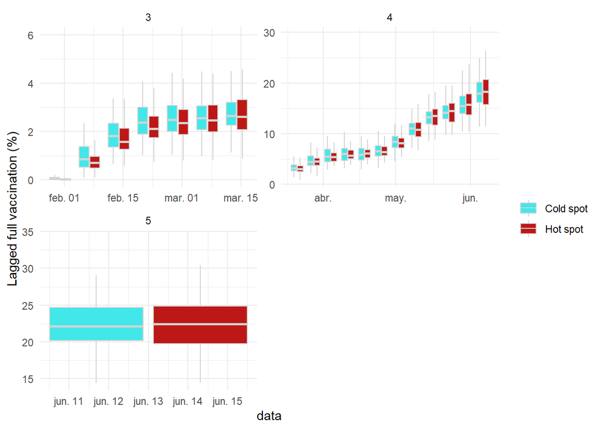

In the third wave, spatio-temporal hot spots have lower percentages of the lagged full vaccination, meanwhile in the four wave differences are not clear.

Figure 22: Difference on the vaccination rates between hot/cold spots given by the posterior RR effect of the raw model on hospitalizations

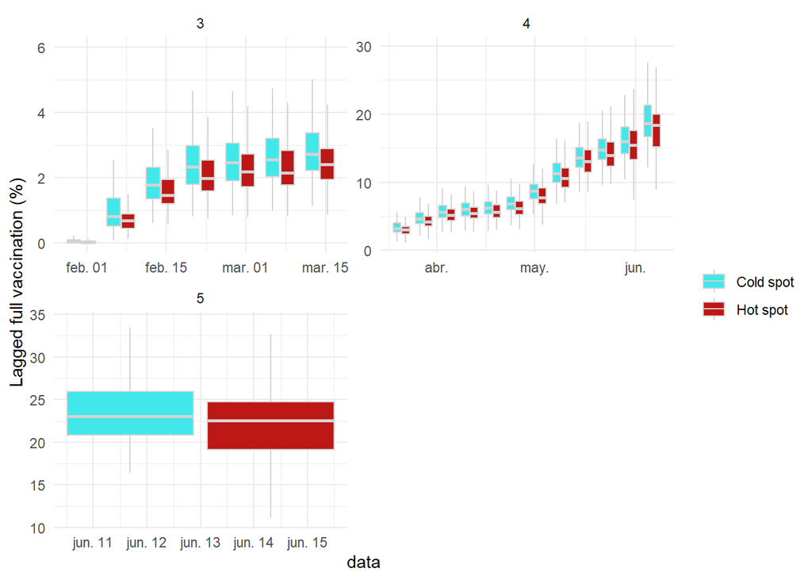

In both waves it seems that hot spots have lower percentages of vaccination.

Table 12: Description of estimated DIC and WAIC for all the models

|  | Cases DIC | Cases WAIC | Hospitalization DIC | Hospitalization WAIC |
| --- | --- | --- | --- | --- |
| Raw | 48398.21 | 48594.42 | 28112.26 | 27703.04 |
| Vaccination |  |  | 28107.77 | 27699.40 |
| Vaccination + Covariates | 48394.29 | 48585.89 | 28108.20 | 27700.66 |
| Vaccination (2-week lag) | 48396.26 | 48590.46 | 28108.33 | 27699.84 |

For both outcomes, adjusted models perform better.

Table 13: Estimated fixed effects and hyperparameters for each model on the cases outcome

|  | Raw | Vaccination + Covariates | Vaccination (2-week lag) |
| --- | --- | --- | --- |
| **Fixed effects** |  |  |  |
| (Intercept) | 0.89 (0.87, 0.9) | 0.85 (0.81, 0.88) | 0.85 (0.81, 0.89) |
| Urban vs Rural |  | 1.09 (1.01, 1.18) | 1.09 (1.01, 1.18) |
| Socioeconomic Index (SI) |  | 1.02 (0.99, 1.04) | 1.02 (0.99, 1.05) |
| Full vaccination (1-week lag) |  | 0.96 (0.93, 1) |  |
| Full vaccination (2-week lags) |  |  | 1 (0.96, 1.03) |
| **Random effects** |  |  |  |
| SD (idarea) | 0.28 (0.32, 0.25) | 0.27 (0.31, 0.24) | 0.28 (0.32, 0.26) |
| Phi for idarea | 0.79 (0.61, 0.91) | 0.75 (0.52, 0.91) | 0.82 (0.69, 0.92) |
| SD (idtime) | 0 (0.05, 0) | 0 (0.01, 0) | 0.02 (0.04, 0.01) |
| SD (idareatime) | 0.32 (0.33, 0.31) | 0.32 (0.33, 0.31) | 0.32 (0.33, 0.31) |

The vaccination has a protective effect over the SIR of cases (4%) when adjusted by covariates. The effect disappears considerin 2-week lags.

The role of the structural spatial effect decreases a little bit when adjusting by the vaccination and the covariates.

Table 14: Percentage of explained variability by the spatial, temporal and spatio-temporal patterns of every model on the cases outcome

|  | Variance Spatial (%) | Variance Temporal (%) | Variance Spatio-Temporal (%) |
| --- | --- | --- | --- |
| Raw | 44.49 | 0.21 | 55.30 |
| Vaccination + Covariates | 43.80 | 0.02 | 56.19 |
| Vaccination (2-week lag) | 44.73 | 0.31 | 54.96 |

Values are very similar.

Table 15: Estimated fixed effects and hyperparameters for each model on the hospitalization outcome

|  | Raw | Vaccination | Vaccination + Covariates | Vaccination (2-week lag) |
| --- | --- | --- | --- | --- |
| **Fixed effects** |  |  |  |  |
| (Intercept) | 0.88 (0.85, 0.9) | 0.87 (0.85, 0.9) | 0.8 (0.75, 0.85) | 0.8 (0.75, 0.85) |
| Full vaccination (1-week lag) |  | 0.96 (0.92, 1) | 0.97 (0.93, 1.02) |  |
| Urban vs Rural |  |  | 1.2 (1.07, 1.35) | 1.2 (1.07, 1.34) |
| Socioeconomic Index (SI) |  |  | 1.18 (1.13, 1.24) | 1.18 (1.13, 1.24) |
| Full vaccination (2-week lag) |  |  |  | 0.98 (0.94, 1.01) |
| **Random effects** |  |  |  |  |
| SD (idarea) | 0.44 (0.5, 0.4) | 0.44 (0.5, 0.39) | 0.38 (0.43, 0.34) | 0.38 (0.43, 0.34) |
| Phi for idarea | 0.69 (0.49, 0.86) | 0.68 (0.46, 0.86) | 0.6 (0.38, 0.78) | 0.6 (0.38, 0.78) |
| SD (idtime) | 0 (0.02, 0) | 0.01 (0.02, 0) | 0.02 (0.03, 0.01) | 0.02 (0.03, 0.01) |
| SD (idareatime) | 0.2 (0.22, 0.19) | 0.2 (0.22, 0.19) | 0.2 (0.22, 0.19) | 0.2 (0.22, 0.19) |

The vaccination effect is at limit of the significance (4% alone and 3% when adjusting by covariates).

The role of the structured effect decreases for the adjusted models by the covariates.

Table 16: Percentage of explained variability by the spatial, temporal and spatio-temporal patterns of every model on the hospitalization outcome

|  | Variance Spatial (%) | Variance Temporal (%) | Variance Spatio-Temporal (%) |
| --- | --- | --- | --- |
| Raw | 82.64 | 0.04 | 17.32 |
| Vaccination | 82.26 | 0.04 | 17.70 |
| Vaccination + Covariates | 77.37 | 0.27 | 22.36 |
| Vaccination (2-week lag) | 77.33 | 0.27 | 22.40 |

The spatial variance slightly decreases for the adjusted models in benefit of the spatio-temporal variance.

#### 2.2.1.2 SIR whole period

First, let’s illustrate the differences in the cumulative full vaccination percentages in all the period between hospitalization hot/cold spots estimated by the raw model.

Figure 23: Difference on the vaccination rates between hot/mild/cold spots given by the residual spatial effect of the raw model on hospitalizations

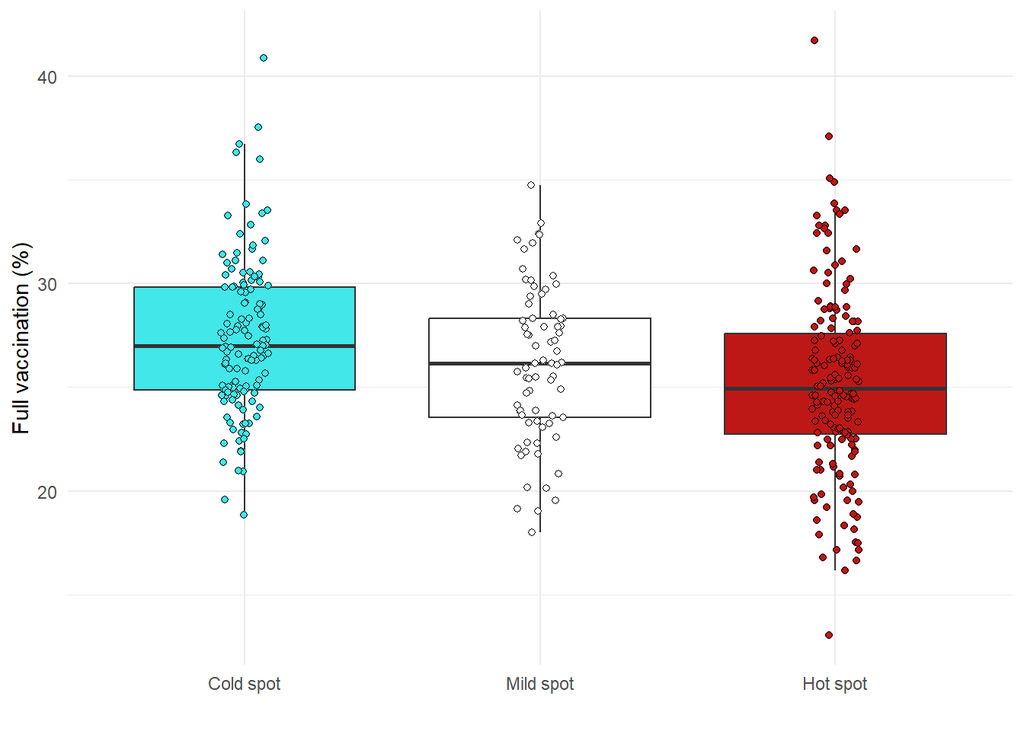

Hot spots have lower full vaccination percentages than cold spots, so we might think that the vaccination could explain some of the spatial effect.

Let’s show the differences on the cumulative full vaccination percentage of the previous week between the estimated hot/cold spots of the actual week, for all the weeks of the study period.

Figure 24: Difference on the vaccination rates between hot/cold spots given by the residual spatio-temporal effect of the raw model on hospitalizations

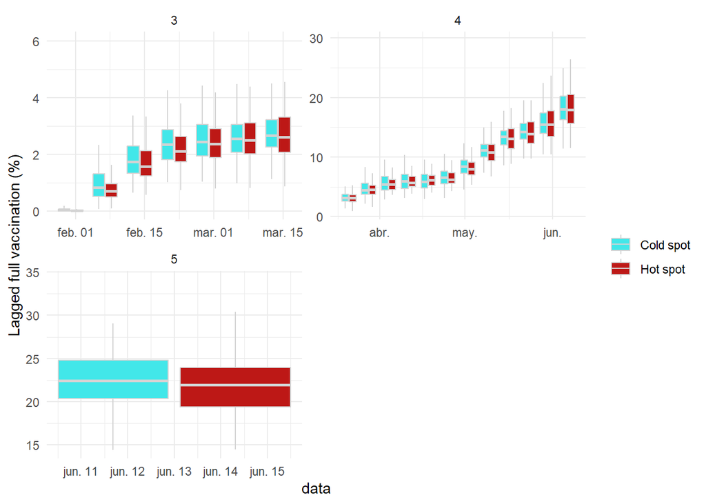

Hot spots have slightly lower percentages of vaccination between hot/cold spots given by the spatio-temporal effect.

Figure 25: Difference on the vaccination rates between hot/cold spots given by the posterior RR effect of the raw model on hospitalizations

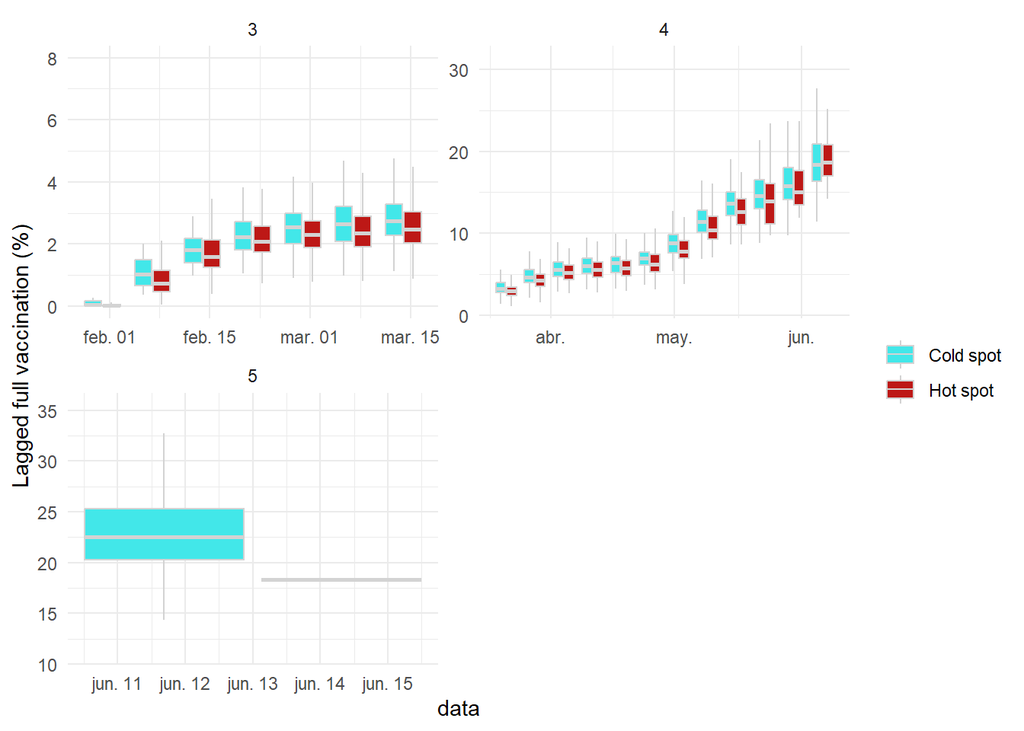

Hot spots have lower percentages of vaccination for this period. We can see how considering SIR for the whole periods in the beginning of the 3rd wave because there is a small incidence of hospitalizations there’re almost no hot spots.

Table 17: Description of estimated DIC and WAIC for all the models

|  | Cases DIC | Cases WAIC | Hospitalization DIC | Hospitalization WAIC |
| --- | --- | --- | --- | --- |
| Raw | 48402.54 | 48586.62 | 28133.75 | 27720.94 |
| Vaccination |  |  | 28131.57 | 27720.44 |
| Vaccination + Covariates | 48392.22 | 48572.68 | 28133.58 | 27724.02 |
| Vaccination (2-week lag) | 48396.26 | 48590.46 | 28108.33 | 27699.84 |

Table 18: Estimated fixed effects and hyperparameters for each model on the cases outcome

|  | Raw | Vaccination + Covariates | Vaccination (2-week lag) |
| --- | --- | --- | --- |
| **Fixed effects** |  |  |  |
| (Intercept) | 0.38 (0.37, 0.38) | 0.36 (0.34, 0.37) | 0.85 (0.81, 0.89) |
| Urban vs Rural |  | 1.1 (1.02, 1.18) | 1.09 (1.01, 1.18) |
| Socioeconomic Index (SI) |  | 1.01 (0.98, 1.03) | 1.02 (0.99, 1.05) |
| Full vaccination (1-week lag) |  | 0.85 (0.78, 0.93) |  |
| Full vaccination (2-week lags) |  |  | 1 (0.96, 1.03) |
| **Random effects** |  |  |  |
| SD (idarea) | 0.28 (0.31, 0.25) | 0.28 (0.31, 0.25) | 0.28 (0.32, 0.26) |
| Phi for idarea | 0.76 (0.61, 0.88) | 0.78 (0.6, 0.9) | 0.82 (0.69, 0.92) |
| SD (idtime) | 0.17 (0.26, 0.12) | 0.16 (0.24, 0.1) | 0.02 (0.04, 0.01) |
| SD (idareatime) | 0.32 (0.33, 0.31) | 0.32 (0.33, 0.31) | 0.32 (0.33, 0.31) |

Vaccination has a protective effect of 15%. Considering 2-week lags this effect disappears.

The role of the structural spatial effect increases for the adjusted model.

Table 19: Percentage of explained variability by the spatial, temporal and spatio-temporal patterns of every model on the cases outcome

|  | Variance Spatial (%) | Variance Temporal (%) | Variance Spatio-Temporal (%) |
| --- | --- | --- | --- |
| Raw | 36.65 | 15.99 | 47.36 |
| Vaccination + Covariates | 36.92 | 13.72 | 49.36 |
| Vaccination (2-week lag) | 44.73 | 0.30 | 54.97 |

The spatial variance increases a little bit in detriment of the temporal variance. The spatio-temporal variance also increases.

Table 20: Estimated fixed effects and hyperparameters for each model on the hospitalization outcome

|  | Raw | Vaccination | Vaccination + Covariates | Vaccination (2-week lag) |
| --- | --- | --- | --- | --- |
| **Fixed effects** |  |  |  |  |
| (Intercept) | 0.95 (0.93, 0.98) | 0.95 (0.92, 0.98) | 0.87 (0.81, 0.93) | 0.8 (0.75, 0.85) |
| Full vaccination (1-week lag) |  | 0.77 (0.69, 0.86) | 0.82 (0.73, 0.92) |  |
| Urban vs Rural |  |  | 1.21 (1.08, 1.35) | 1.2 (1.07, 1.34) |
| Socioeconomic Index (SI) |  |  | 1.17 (1.12, 1.22) | 1.18 (1.13, 1.24) |
| Full vaccination (2-week lags) |  |  |  | 0.98 (0.94, 1.01) |
| **Random effects** |  |  |  |  |
| SD (idarea) | 0.44 (0.49, 0.41) | 0.43 (0.48, 0.39) | 0.38 (0.43, 0.34) | 0.38 (0.43, 0.34) |
| Phi for idarea | 0.69 (0.53, 0.82) | 0.67 (0.48, 0.84) | 0.6 (0.4, 0.79) | 0.6 (0.38, 0.78) |
| SD (idtime) | 0.14 (0.21, 0.11) | 0.11 (0.17, 0.08) | 0.12 (0.18, 0.09) | 0.02 (0.03, 0.01) |
| SD (idareatime) | 0.2 (0.22, 0.19) | 0.2 (0.22, 0.19) | 0.2 (0.22, 0.19) | 0.2 (0.22, 0.19) |

The vaccination effect has a protective effect of the 18% adjusted by covariates. Considering 2-week lags the effect is very small at limit of significance.

The role of the structured effect decreases for the adjusted models.

Table 21: Percentage of explained variability by the spatial, temporal and spatio-temporal patterns of every model on the hospitalization outcome

|  | Variance Spatial (%) | Variance Temporal (%) | Variance Spatio-Temporal (%) |
| --- | --- | --- | --- |
| Raw | 75.03 | 9.25 | 15.73 |
| Vaccination | 77.15 | 5.75 | 17.10 |
| Vaccination + Covariates | 71.84 | 7.83 | 20.34 |
| Vaccination (2-week lag) | 77.38 | 0.27 | 22.35 |

Adjusted model with vaccination and covariates has a lower spatial variance and higher spatio-temporal one.

### 2.2.2 Population >= 70 years old

Figure 19: Plot of the evolution of the distribution of fully vaccinated percentage between areas (the median along with the interquantile range is represented) across the 3rd and 4th wave

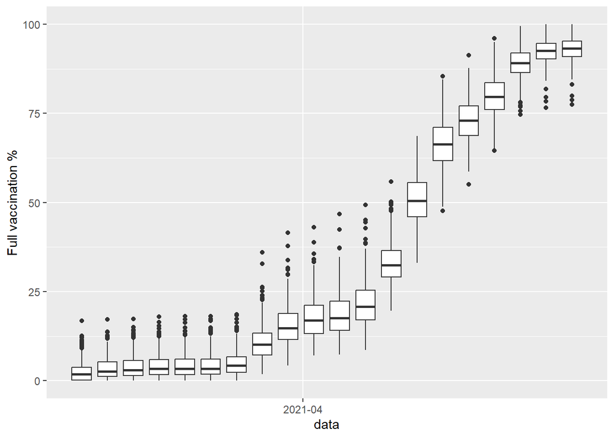

#### 2.2.2.1 SIR by week

First, let’s illustrate the differences in the cumulative full vaccination percentages in all the period between hospitalization hot/cold spots estimated by the raw model.

Figure 26: Difference on the vaccination rates between hot/mild/cold spots given by the residual spatial effect of the raw model on hospitalizations

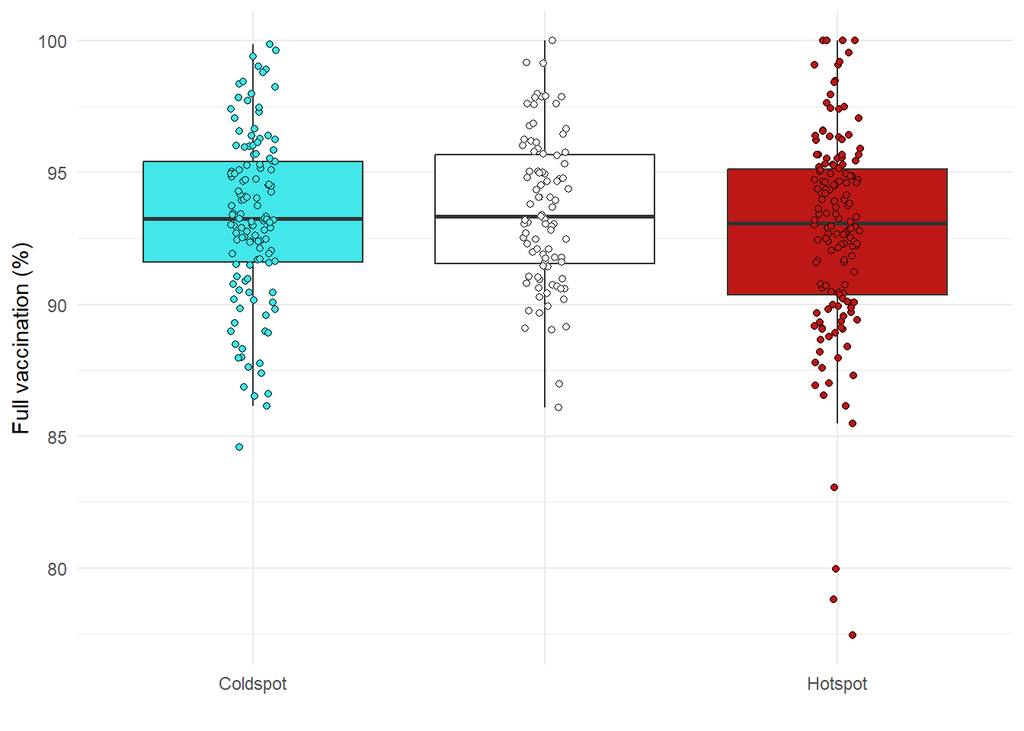

Hotspots have slightly lower full vaccination coverage than the rest.

Let’s explore the linearity of the relationships between the cumulative vaccination at the end of the studied period and the estimated spatial RR by the raw model.

Figure 27: Plot of the estimated spatial RR of the raw model on hospitalisations for each ABS in function of the fully vaccination that we will include in the model

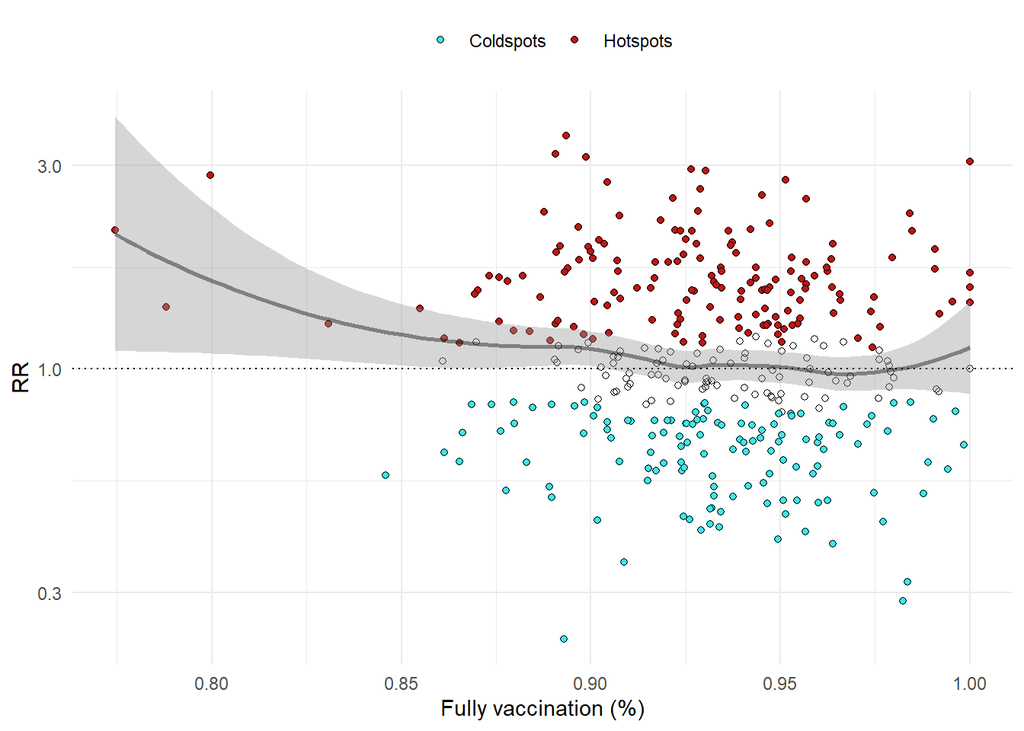

Table 22: Description of estimated DIC and WAIC the raw and adjusted model

|  | DIC | WAIC |
| --- | --- | --- |
| Raw | 20606.16 | 20231.18 |
| Vaccination (1-week lag) | 20600.79 | 20228.24 |
| Vaccination (2-week lag) | 20597.04 | 20227.90 |

The adjusted model fits slightly better the data.

Table 23: Estimated fixed effects and hyperparameters for each model on the hospitalization outcome

|  | Raw | Vaccination (1-week lag) | Vaccination (2-week lag) |
| --- | --- | --- | --- |
| **Fixed effects** |  |  |  |
| (Intercept) | 0.81 (0.78, 0.85) | 0.72 (0.66, 0.78) | 0.72 (0.66, 0.78) |
| Urban vs Rural |  | 1.28 (1.1, 1.48) | 1.28 (1.1, 1.49) |
| Socioeconomic Index (SI) |  | 1.15 (1.08, 1.21) | 1.15 (1.08, 1.22) |
| Full vaccination (1-week lag) |  | 0.94 (0.88, 1) |  |
| Full vaccination (2-week lags) |  |  | 0.95 (0.9, 0.99) |
| **Random effects** |  |  |  |
| SD (idarea) | 0.53 (0.6, 0.47) | 0.48 (0.54, 0.43) | 0.49 (0.55, 0.44) |
| Phi for idarea | 0.65 (0.39, 0.83) | 0.62 (0.42, 0.82) | 0.62 (0.41, 0.81) |
| SD (idtime) | 0.02 (0.03, 0.01) | 0 (0.03, 0) | 0.02 (0.04, 0.01) |
| SD (idareatime) | 0.26 (0.28, 0.24) | 0.26 (0.28, 0.24) | 0.26 (0.28, 0.24) |

Now, the vaccination has a protective effect of 6%. Urban areas have a risk effect of 28% and SI index a risk effect of 15%. The effect of vaccination is of 5% when taking 2-week lags.

Table 24: Percentage of explained variability by the spatial, temporal and spatio-temporal patterns of every model on the hospitalization outcome

|  | Variance Spatial (%) | Variance Temporal (%) | Variance Spatio-Temporal (%) |
| --- | --- | --- | --- |
| Raw | 80.38 | 0.14 | 19.48 |
| Vaccination (1-week lag) | 77.41 | 0.08 | 22.50 |
| Vaccination (2-week lag) | 78.27 | 0.18 | 21.55 |

The spatial variance decreases a little in benefit of the spatio-temporal variance.

#### 2.2.2.2 SIR whole period

Table 25: Estimated fixed effects and hyperparameters for each model on the hospitalization outcome

|  | Raw | Vaccination (1-week lag) | Vaccination (2-week lag) |
| --- | --- | --- | --- |
| **Fixed effects** |  |  |  |
| (Intercept) | 0.73 (0.7, 0.76) | 0.65 (0.59, 0.71) | 0.65 (0.59, 0.71) |
| Urban vs Rural |  | 1.26 (1.09, 1.47) | 1.27 (1.09, 1.48) |
| Socioeconomic Index (SI) |  | 1.14 (1.08, 1.21) | 1.14 (1.08, 1.21) |
| Full vaccination (1-week lag) |  | 0.7 (0.58, 0.85) |  |
| Full vaccination (2-week lags) |  |  | 0.79 (0.67, 0.93) |
| **Random effects** |  |  |  |
| SD (idarea) | 0.53 (0.58, 0.48) | 0.5 (0.56, 0.44) | 0.49 (0.54, 0.45) |
| Phi for idarea | 0.65 (0.43, 0.84) | 0.62 (0.42, 0.8) | 0.6 (0.46, 0.72) |
| SD (idtime) | 0.2 (0.29, 0.15) | 0.15 (0.23, 0.11) | 0.18 (0.26, 0.14) |
| SD (idareatime) | 0.26 (0.28, 0.24) | 0.26 (0.28, 0.24) | 0.26 (0.28, 0.24) |

The vaccination has a bigger protective effect of 30% over hospitalizations. The SI index has a risk effect of 14% and the urban areas a risk effect of 26%. The effect of vaccination is of 21% when taking 2-week lags.

Table 26: Percentage of explained variability by the spatial, temporal and spatio-temporal patterns of every model on the hospitalization outcome

|  | Variance Spatial (%) | Variance Temporal (%) | Variance Spatio-Temporal (%) |
| --- | --- | --- | --- |
| Raw | 71.15 | 11.51 | 17.33 |
| Vaccination (1-week lag) | 72.49 | 7.91 | 19.59 |
| Vaccination (2-week lag) | 70.15 | 10.63 | 19.21 |

The spatial and spatio-temporal variance increases in detriment of the temporal one.

## 2.3 5th wave

Figure 28: Plot of the evolution of the distribution of fully vaccinated percentage between areas (the median along with the interquantile range is represented) across the 5th wave

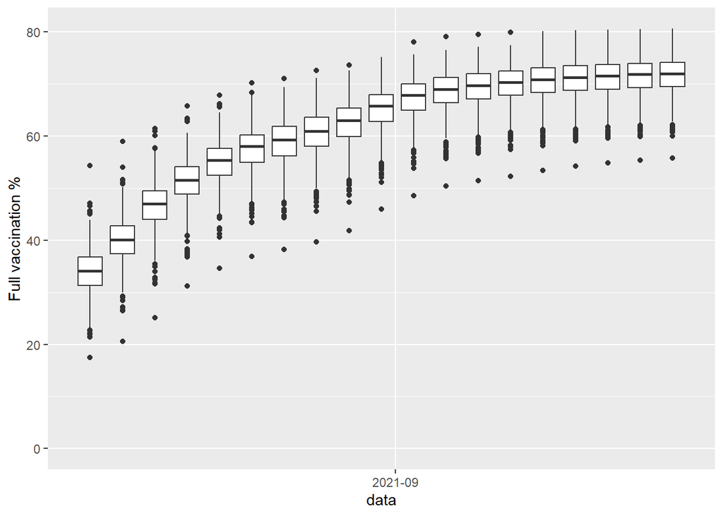